# Homework 5

Josephine Wright

2026-01-22

## Instructions

Answer the following questions and/or complete the exercises in RMarkdown. Please embed all of your code and push the final work to your repository. Your report should be organized, clean, and run free from errors. Remember, you must remove the `#` for any included code chunks to run. Any plots must have appropriate titles and aesthetics.

## Load the tidyverse

```r
library("tidyverse")
options(scipen=999) #turn off scientific notation
```

## Data

**Database of vertebrate home range sizes.** Reference: Tamburello N, Cote IM, Dulvy NK (2015) Energy and the scaling of animal space use. The American Naturalist 186(2):196-211. http://dx.doi.org/10.1086/682070.  
Data: http://datadryad.org/resource/doi:10.5061/dryad.q5j65/1

**1. Load the data into a new object called `homerange`.**

```r
homerange <- read_csv("data/Tamburelloetal_HomeRangeDatabase.csv")
```

**2. What is the structure of the `homerange` data? Does it have any NA’s? Do a quick exploratory analysis of your choice below.**

```r
str(homerange)
```

```
## spc_tbl_ [569 × 24] (S3: spec_tbl_df/tbl_df/tbl/data.frame)
##  $ taxon                     : chr [1:569] "lake fishes" "river fishes" "river fishes" "river fishes" ...
##  $ common.name               : chr [1:569] "american eel" "blacktail redhorse" "central stoneroller" "rosyside dace" ...
##  $ class                     : chr [1:569] "actinopterygii" "actinopterygii" "actinopterygii" "actinopterygii" ...
##  $ order                     : chr [1:569] "anguilliformes" "cypriniformes" "cypriniformes" "cypriniformes" ...
##  $ family                    : chr [1:569] "anguillidae" "catostomidae" "cyprinidae" "cyprinidae" ...
##  $ genus                     : chr [1:569] "anguilla" "moxostoma" "campostoma" "clinostomus" ...
##  $ species                   : chr [1:569] "rostrata" "poecilura" "anomalum" "funduloides" ...
##  $ primarymethod             : chr [1:569] "telemetry" "mark-recapture" "mark-recapture" "mark-recapture" ...
##  $ N                         : chr [1:569] "16" NA "20" "26" ...
##  $ mean.mass.g               : num [1:569] 887 562 34 4 4 ...
##  $ log10.mass                : num [1:569] 2.948 2.75 1.531 0.602 0.602 ...
##  $ alternative.mass.reference: chr [1:569] NA NA NA NA ...
##  $ mean.hra.m2               : num [1:569] 282750 282.1 116.1 125.5 87.1 ...
##  $ log10.hra                 : num [1:569] 5.45 2.45 2.06 2.1 1.94 ...
##  $ hra.reference             : chr [1:569] "Minns, C. K. 1995. Allometry of home range size in lake and river fishes. Canadian Journal of Fisheries and Aquatic Sciences 52 "Minns, C. K. 1995. Allometry of home range size in lake and river fishes. Canadian Journal of Fisheries and Aquatic Sciences…
##  $ realm                     : chr [1:569] "aquatic" "aquatic" "aquatic" "aquatic" ...
##  $ thermoregulation          : chr [1:569] "ectotherm" "ectotherm" "ectotherm" "ectotherm" ...
##  $ locomotion                : chr [1:569] "swimming" "swimming" "swimming" "swimming" ...
##  $ trophic.guild             : chr [1:569] "carnivore" "carnivore" "carnivore" "carnivore" ...
##  $ dimension                 : num [1:569] 3 2 2 2 2 2 2 2 2 2 ...
##  $ preymass                  : num [1:569] NA NA NA NA NA NA 1.39 NA NA NA ...
##  $ log10.preymass            : num [1:569] NA NA NA NA NA ...
##  $ PPMR                      : num [1:569] NA NA NA NA NA NA 530 NA NA NA ...
##  $ prey.size.reference       : chr [1:569] NA NA NA NA ...
##  - attr(*, "spec")=
##   .. cols(
##   ..   taxon = col_character(),
##   ..   common.name = col_character(),
##   ..   class = col_character(),
##   ..   order = col_character(),
##   ..   family = col_character(),
##   ..   genus = col_character(),
##   ..   species = col_character(),
##   ..   primarymethod = col_character(),
##   ..   N = col_character(),
##   ..   mean.mass.g = col_double(),
##   ..   log10.mass = col_double(),
##   ..   alternative.mass.reference = col_character(),
##   ..   mean.hra.m2 = col_double(),
##   ..   log10.hra = col_double(),
##   ..   hra.reference = col_character(),
##   ..   realm = col_character(),
##   ..   thermoregulation = col_character(),
##   ..   locomotion = col_character(),
##   ..   trophic.guild = col_character(),
##   ..   dimension = col_double(),
##   ..   preymass = col_double(),
##   ..   log10.preymass = col_double(),
##   ..   PPMR = col_double(),
##   ..   prey.size.reference = col_character()
##   .. )
##  - attr(*, "problems")=<externalptr>
```

```r
glimpse(homerange)
```

```
## Rows: 569
## Columns: 24
## $ taxon                      <chr> "lake fishes", "river fishes", "river fishe…
## $ common.name                <chr> "american eel", "blacktail redhorse", "cent…
## $ class                      <chr> "actinopterygii", "actinopterygii", "actino…
## $ order                      <chr> "anguilliformes", "cypriniformes", "cyprini…
## $ family                     <chr> "anguillidae", "catostomidae", "cyprinidae"…
## $ genus                      <chr> "anguilla", "moxostoma", "campostoma", "cli…
## $ species                    <chr> "rostrata", "poecilura", "anomalum", "fundu…
## $ primarymethod              <chr> "telemetry", "mark-recapture", "mark-recapt…
## $ N                          <chr> "16", NA, "20", "26", "17", "5", "2", "2", …
## $ mean.mass.g                <dbl> 887.00, 562.00, 34.00, 4.00, 4.00, 3525.00,…
## $ log10.mass                 <dbl> 2.9479236, 2.7497363, 1.5314789, 0.6020600,…
## $ alternative.mass.reference <chr> NA, NA, NA, NA, NA, NA, NA, NA, NA, NA, NA,…
## $ mean.hra.m2                <dbl> 282750.00, 282.10, 116.11, 125.50, 87.10, 3…
## $ log10.hra                  <dbl> 5.4514026, 2.4504031, 2.0648696, 2.0986437,…
## $ hra.reference              <chr> "Minns, C. K. 1995. Allometry of home range…
## $ realm                      <chr> "aquatic", "aquatic", "aquatic", "aquatic",…
## $ thermoregulation           <chr> "ectotherm", "ectotherm", "ectotherm", "ect…
## $ locomotion                 <chr> "swimming", "swimming", "swimming", "swimmi…
## $ trophic.guild              <chr> "carnivore", "carnivore", "carnivore", "car…
## $ dimension                  <dbl> 3, 2, 2, 2, 2, 2, 2, 2, 2, 2, 2, 2, 2, 3, 3…
## $ preymass                   <dbl> NA, NA, NA, NA, NA, NA, 1.39, NA, NA, NA, N…
## $ log10.preymass             <dbl> NA, NA, NA, NA, NA, NA, 0.1430148, NA, NA, …
## $ PPMR                       <dbl> NA, NA, NA, NA, NA, NA, 530, NA, NA, NA, NA…
## $ prey.size.reference        <chr> NA, NA, NA, NA, NA, NA, "Brose U, et al. 20…
```

```r
names(homerange)
```

```
##  [1] "taxon"                      "common.name"
##  [3] "class"                      "order"
##  [5] "family"                     "genus"
##  [7] "species"                    "primarymethod"
##  [9] "N"                          "mean.mass.g"
## [11] "log10.mass"                 "alternative.mass.reference"
## [13] "mean.hra.m2"                "log10.hra"
## [15] "hra.reference"              "realm"
## [17] "thermoregulation"           "locomotion"
## [19] "trophic.guild"              "dimension"
## [21] "preymass"                   "log10.preymass"
## [23] "PPMR"                       "prey.size.reference"
```

**3. Which animal groups are represented in the data? Make a plot that shows the number in each class.**

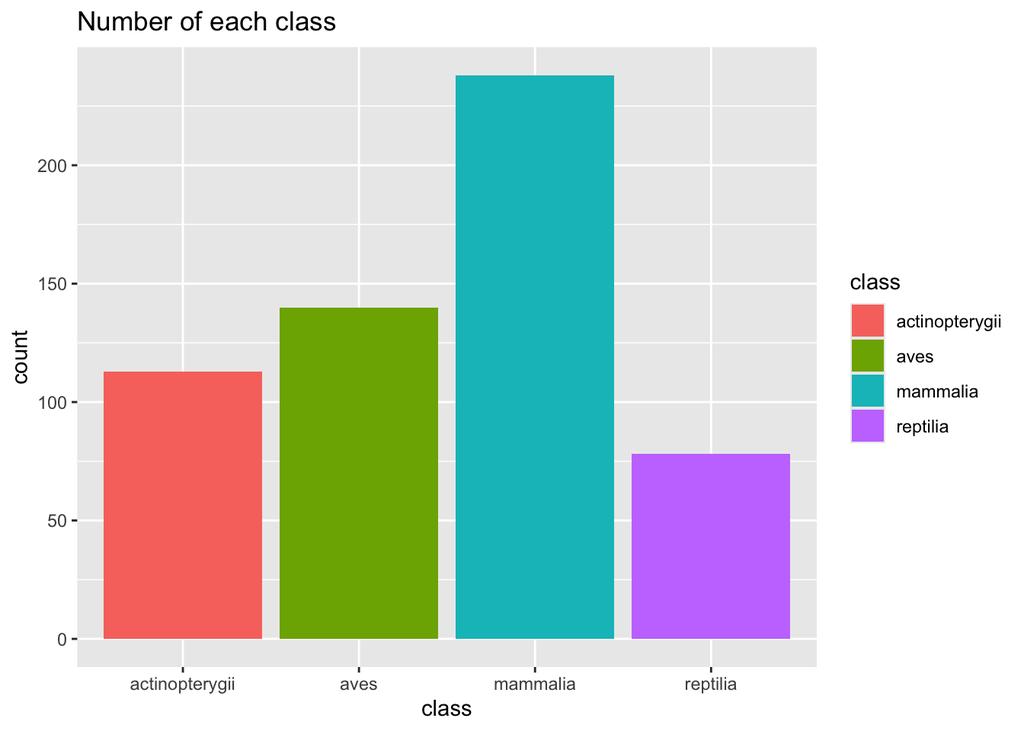

```r
ggplot(data=homerange,
       mapping=aes(x=class))+
  geom_bar(mapping=aes(fill=class))+
  labs(title="Number of each class")
```

**4. Are there more carnivores or herbivores represented in the data? Make a plot that shows the number in each trophic guild.**

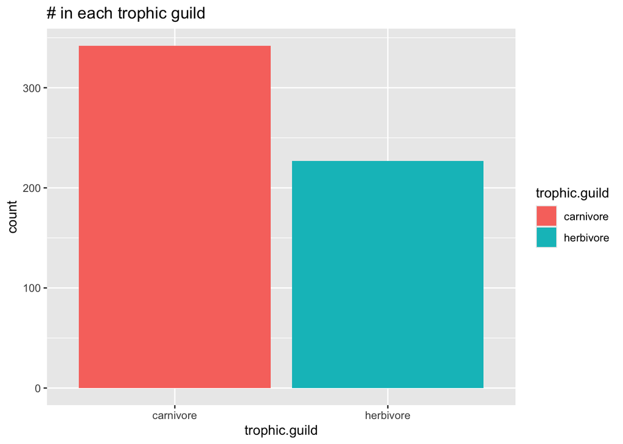

```r
ggplot(data=homerange,
       mapping=aes(x=trophic.guild))+
  geom_bar(mapping=aes(fill=trophic.guild))+
  labs(title="# in each trophic guild")
```

There are more carnivores represented in the data (~340 carnivores vs. ~225 herbivores).

```r
homerange %>%
  select(trophic.guild, common.name, order, mean.hra.m2, mean.mass.g) %>%
  filter(trophic.guild=="herbivore") %>%
  filter(mean.hra.m2>1000000) %>%
  slice_min(mean.hra.m2, n=10) %>%
   arrange(desc(mean.hra.m2))
```

```
## # A tibble: 10 × 5
##    trophic.guild common.name              order        mean.hra.m2 mean.mass.g
##    <chr>         <chr>                    <chr>              <dbl>       <dbl>
##  1 herbivore     hartebeest               artiodactyla    2176858.     136000.
##  2 herbivore     leopard tortoise         testudines      2050000       10600
##  3 herbivore     black grouse             galliformes     1975000        1139
##  4 herbivore     mountain gazelle         artiodactyla    1872837.      21475.
##  5 herbivore     desert warthog           artiodactyla    1742007.      80514.
##  6 herbivore     cape porcupine           rodentia        1689779.      17000.
##  7 herbivore     black-tailed jackrabbit  lagomorpha      1592759.       2268.
##  8 herbivore     Indian crested porcupine rodentia        1411985.      15000.
##  9 herbivore     red-footed tortoise      testudines      1384160        6167.
## 10 herbivore     red panda                carnivora       1024991.       5400.
```

**6. Which two species have the largest and smallest homerange sizes?**

```r
homerange %>%
  select(species, mean.hra.m2) %>%
  slice_min(mean.hra.m2, n=1)
```

```
## # A tibble: 1 × 2
##   species  mean.hra.m2
##   <chr>          <dbl>
## 1 hipoliti        0.03
```

```r
homerange %>%
  select(species, mean.hra.m2) %>%
  slice_max(mean.hra.m2, n=1)
```

```
## # A tibble: 1 × 2
##   species  mean.hra.m2
##   <chr>          <dbl>
## 1 tarandus  3550830977
```

**7. Which carnivorous mammals have the largest homeranges?**

```r
homerange %>%
  select(species, trophic.guild, mean.hra.m2) %>%
  filter(trophic.guild=="carnivore") %>%
  slice_max(mean.hra.m2, n=1)
```

```
## # A tibble: 1 × 3
##   species trophic.guild mean.hra.m2
##   <chr>   <chr>               <dbl>
## 1 jubatus carnivore      815060788.
```

**8. Is there a relationship between body mass and homerange size? Make a scatterplot to show this relationship. Be sure to include appropriate labels and a title.**

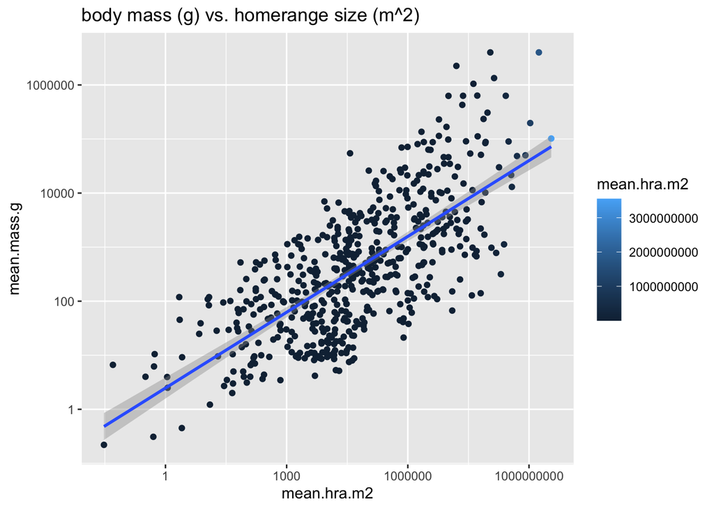

```r
ggplot(data=homerange,
       mapping=aes(x=mean.hra.m2, y=mean.mass.g))+
  geom_point(mapping=aes(color=mean.hra.m2))+
    scale_y_log10()+
    scale_x_log10()+
  geom_smooth(method=lm, se=T)+
  labs(title="body mass (g) vs. homerange size (m^2)")
```

Yes, there is a positive relationship between home range (in meters squared) and body mass (in grams)

**9. Use filter to extract the data for only birds and mammals. Then make a plot that compares the homerange sizes of these two groups. Be sure to include appropriate labels and a title.**

```r
mammals_and_birds <- filter(homerange, taxon=="mammals" | taxon=="birds")
mammals_and_birds
```

```
## # A tibble: 378 × 24
##    taxon common.name        class order family genus species primarymethod N
##    <chr> <chr>              <chr> <chr> <chr>  <chr> <chr>   <chr>         <chr>
##  1 birds golden eagle       aves  acci… accip… aqui… chrysa… telemetry*    <NA>
##  2 birds common buzzard     aves  acci… accip… buteo buteo   telemetry*    <NA>
##  3 birds short-toed snake … aves  acci… accip… circ… gallic… telemetry*    <NA>
##  4 birds Bonelli's eagle    aves  acci… accip… hier… fascia… telemetry*    <NA>
##  5 birds booted eagle       aves  acci… accip… hier… pennat… telemetry     4
##  6 birds Egyptian vulture   aves  acci… accip… neop… percno… telemetry*    <NA>
##  7 birds gadwall            aves  anse… anati… anas  strepe… telemetry     3
##  8 birds northern brown ki… aves  apte… apter… apte… austra… telemetry     6
##  9 birds European nightjar  aves  capr… capri… capr… europa… telemetry*    <NA>
## 10 birds oystercatcher      aves  char… haema… haem… ostral… telemetry     8
## # ℹ 368 more rows
## # ℹ 15 more variables: mean.mass.g <dbl>, log10.mass <dbl>,
## #   alternative.mass.reference <chr>, mean.hra.m2 <dbl>, log10.hra <dbl>,
## #   hra.reference <chr>, realm <chr>, thermoregulation <chr>, locomotion <chr>,
## #   trophic.guild <chr>, dimension <dbl>, preymass <dbl>, log10.preymass <dbl>,
## #   PPMR <dbl>, prey.size.reference <chr>
```

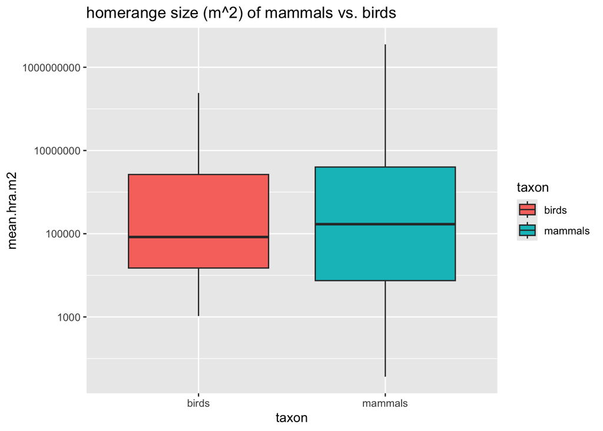

```r
ggplot(data=mammals_and_birds,
  mapping=aes(x=taxon, y=mean.hra.m2))+
  geom_boxplot(mapping=aes(fill=taxon))+
  scale_y_log10()+
labs(title="homerange size (m^2) of mammals vs. birds")
```

**10. Do one additional exploratory analysis of your choice. Before writing the code, write the question you are trying to answer. The question should be biologically meaningful and appropriate for the data. It must include at least one `filter()`, `select()`, and `arrange()`.**

Which mammals have a homerange smaller than or equal to 30,000 m^2? Find the top 20 in ascending order and include common name, locomotion, homerange, and mass.

```r
homerange %>%
  select(trophic.guild, taxon, common.name, locomotion, mean.hra.m2, mean.mass.g) %>%
  filter(taxon=="mammals") %>%
  filter(trophic.guild=="carnivore") %>%
  filter(mean.hra.m2<=30000) %>%
  slice_min(mean.hra.m2, n=20) %>%
   arrange(mean.hra.m2)
```

```
## # A tibble: 20 × 6
##    trophic.guild taxon   common.name          locomotion mean.hra.m2 mean.mass.g
##    <chr>         <chr>   <chr>                <chr>            <dbl>       <dbl>
##  1 carnivore     mammals long-clawed shrew    walking           77.6       14.1
##  2 carnivore     mammals east African mole r… walking          100        257
##  3 carnivore     mammals greater white-foote… walking          234.        10
##  4 carnivore     mammals slender shrew        walking          275.         4.37
##  5 carnivore     mammals crowned shrew        walking          372.         9.33
##  6 carnivore     mammals Northern three-stri… walking          468.        19.5
##  7 carnivore     mammals giant golden mole    walking          617.       437.
##  8 carnivore     mammals elegant fat-tailed … walking          708.        29
##  9 carnivore     mammals Roman mole           walking         2829.        81.4
## 10 carnivore     mammals European mole        walking         3004.        96.5
## 11 carnivore     mammals rufous elephant shr… walking         3393.        58
## 12 carnivore     mammals star-nosed mole      walking         3631.        47.9
## 13 carnivore     mammals arctic shrew         walking         4786.         8.13
## 14 carnivore     mammals cotton mouse         walking         5012.        27.5
## 15 carnivore     mammals cinereus shrew       walking         5012.         4.17
## 16 carnivore     mammals eastern mole         walking         7429.       104.
## 17 carnivore     mammals white-footed dunnart walking        11410.        23
## 18 carnivore     mammals four-toed elephant … walking        12000.       201
## 19 carnivore     mammals Southern brown band… walking        21133.       775
## 20 carnivore     mammals southern grasshoppe… walking        25945.        22
```

## Knit and Upload

Please knit your work as an .html file and upload to Canvas. Homework is due before the start of the next lab. No late work is accepted. Make sure to use the formatting conventions of RMarkdown to make your report neat and clean!